# Probability Experiment and Simulation

### Experiment

Ingredients:

- Blue Coin with probability p= .75 of landing on H
- Green Coin with probability p= .4 of landing on H
- Red 6-sided dice with the following probabilities: .1, .1, .3, .3, .1, .1
- Blue 6-sided fair dice
- 52 card deck

Instructions:

- Flip the blue coin twice. If both Heads or both Tails, then pick up the blue dice. If two do not align, then pick up red dice.
- Next roll the given dice.
- If the dice rolls an even number, then pick up the green coin. If dice rolls an odd number, then pick up the blue coin.
- Flip the coin. Then pick up the standard deck.
- If Heads pull cards until the first 7. If Tails, pull cards until the first 9.
- Record the number of cards until you get the desired cards.
- If the number is greater than or equal to 20, then pick up the blue dice. If number is less than 20, then pick up the red dice. Roll the dice and record the response.

Support of $X$: $\{1, 2, 3, 4, 5, 6\}$

We’ll start by describing our events…

- Red dice = rolled when achieve HT or TH flips from the initial coin flip
- Blue dice = rolled when achieve HH or TT flips from the initial coin flip
- Green coin = rolling an even number from the dice
- Blue coin = rolling an odd number from the dice
- H = Achieving H from the aforementioned coin
- T = Achieving T from the aforementioned coin
- Draw >= 20 = If the 7 (H’s case) or 9 (T’s case) is drawn as the 21st card or later.
- Draw < 20= If the 7 (H’s case) or 9 (T’s case) is drawn as the 20th card or before.
- Final red dice = Roll if the number from the last step is LESS THAN 20
- Final blue dice = Roll if the number from the last step is GREATER THAN OR EQUAL TO 20

### Sub-problem

- Flip the blue coin twice. If both Heads or both Tails, then pick up the blue dice. If two do not align, then pick up red dice.
- Next roll the given dice.
- If the dice rolls an even number, then pick up the green coin. If dice rolls an odd number, then pick up the blue coin.
- Flip the coin.

Possible Outcomes: H, T

### Analysis

My strategy is to find the probability of picking up each coin by applying LOTP. Then, we can use the coin probabilities to determine the probabilities of getting H or T.

Recall the events relevant for the sub-problem:

- Red dice = rolled when achieve HT or TH flips from the initial coin flip
- Blue dice = rolled when achieve HH or TT flips from the initial coin flip
- Green coin = rolling an even number from the dice
- Blue coin = rolling an odd number from the dice
- H = Achieving H from the aforementioned coin
- T = Achieving T from the aforementioned coin

$$P(\textrm{Green Coin}) = P(\textrm{Green Coin}|\textrm{Red
Dice})P(\textrm{Red Dice})+P(\textrm{Green Coin}|\textrm{Blue
Dice})P(\textrm{Blue Dice})$$

We’ll start by finding the probabilities of each dice. The probability of choosing the blue dice is

$$P(\textrm{Blue Dice})=(3/4)^2+(1/4)^2=10/16$$
Because the blue dice can be achieved two ways: flipping 2 heads or 2 tails. Since the coin is weighted, the probability of flipping 2 heads is $(3/4)*(3/4)$, where as the probability of flipping 2 tails is $(1/4)*13/4)$.

Similarly,
$$P(\textrm{Red Dice})=2*(3/4)*(1/4)=6/16$$

Since we can flip either HT or TH to achieve the red dice outcome.

Next, we’ll find the conditional probabilities.

$P(\textrm{Green Coin}|\textrm{Blue Dice})=1/2$ since the dice is fair. We have a 1/2 chance of rolling an even number, resulting in the Green Coin being chosen.

Next, we need to find $P(\textrm{Green Coin}|\textrm{Red Dice})$ using LOTP with extra conditioning, as the dice is weighted with the following probabilities: .1, .1, .3, .3, .1, .1. Recall that the green coin is chosen if the dice rolls an even number, so we are calculating the probability of rolling an even number from the red dice. As such, we carry the red dice conditioning throughout the probabilities of rolling each outcome, as these probabilities rely on the weights of the red dice.

$$\begin{eqnarray*}
P(\textrm{Green Coin}|\textrm{Red Dice}) &=& P(\textrm{Even
Roll}|\textrm{Red Dice}) \\
&=& P(\textrm{Even}|\textrm{Roll 1, Red Dice})P(\textrm{Roll
1}|\textrm{Red Dice}) \\
&+& P(\textrm{Even}|\textrm{Roll 2, Red Dice})P(\textrm{Roll
2}|\textrm{Red Dice}) \\
&+& P(\textrm{Even}|\textrm{Roll 3, Red Dice})P(\textrm{Roll
3}|\textrm{Red Dice}) \\
&+& P(\textrm{Even}|\textrm{Roll 4, Red Dice})P(\textrm{Roll
4}|\textrm{Red Dice}) \\
&+& P(\textrm{Even}|\textrm{Roll 5, Red Dice})P(\textrm{Roll
5}|\textrm{Red Dice}) \\
&+& P(\textrm{Even}|\textrm{Roll 6, Red Dice})P(\textrm{Roll
6}|\textrm{Red Dice})
\end{eqnarray*}$$
$P(\textrm{Even}|\textrm{Roll 2, 4, 6, Red Dice})=1$ $P(\textrm{Even}|\textrm{Roll 1, 3, 5, Red Dice})=0$

So, we get:
$$\begin{eqnarray*}
P(\textrm{Green Coin}|\textrm{Red Dice})
&=&P(\textrm{Even}|\textrm{Red Dice}) &=&
P(\textrm{Roll 2, Red Dice}) \\
&+& P(\textrm{Roll 4, Red Dice}) \\
&+& P(\textrm{Roll 6, Red Dice})
\end{eqnarray*}$$

$$\begin{eqnarray*}
P(\textrm{Green Coin}|\textrm{Red Dice}) &=&
P(\textrm{Even}|\textrm{Red Dice}) &=& .1+.3+.1 &=& .5
\end{eqnarray*}$$

Back to our original equation:
$$P(\textrm{Green Coin}) = P(\textrm{Green Coin}|\textrm{Red
Dice})P(\textrm{Red Dice})+P(\textrm{Green Coin}|\textrm{Blue
Dice})P(\textrm{Blue Dice})$$

$$P(\textrm{Green Coin}) = (1/2)*(6/16) + (1/2)*(10/16)= 1/2$$

So, we have a 50% chance of ending with the Green Coin.

Similarly……

$$P(\textrm{Blue Coin}) = P(\textrm{Blue Coin}|\textrm{Red
Dice})P(\textrm{Red Dice})+P(\textrm{Blue Coin}|\textrm{Blue
Dice})P(\textrm{Blue Dice})$$

The probability of choosing the blue dice is

$$P(\textrm{Blue Dice})=(3/4)^2+(1/4)^2=10/16$$

Because the blue dice can be achieved two ways: flipping 2 heads or 2 tails. Since the coin is weighted, the probability of flipping 2 heads is $(3/4)*(3/4)$, where as the probability of flipping 2 tails is $(1/4)*13/4)$.

Similarly,
$$P(\textrm{Red Dice})=2*(3/4)*(1/4)=6/16$$

Since we can flip either HT or TH to achieve the red dice outcome.

Next, we need to find $P(\textrm{Blue Coin}|\textrm{Red Dice})$ using LOTP with extra conditioning, as the dice is weighted with the following probabilities: .1, .1, .3, .3, .1, .1. Recall that the green coin is chosen if the dice rolls an even number, so we are calculating the probability of rolling an even number from the red dice. As such, we carry the red dice conditioning throughout the probabilities of rolling each outcome, as these probabilities rely on the weights of the red dice.

$$\begin{eqnarray*}
P(\textrm{Blue Coin}|\textrm{Red Dice}) &=& P(\textrm{Even
Roll}|\textrm{Red Dice}) \\
&=& P(\textrm{Even}|\textrm{Roll 1, Red Dice})P(\textrm{Roll
1}|\textrm{Red Dice}) \\
&+& P(\textrm{Even}|\textrm{Roll 2, Red Dice})P(\textrm{Roll
2}|\textrm{Red Dice}) \\
&+& P(\textrm{Even}|\textrm{Roll 3, Red Dice})P(\textrm{Roll
3}|\textrm{Red Dice}) \\
&+& P(\textrm{Even}|\textrm{Roll 4, Red Dice})P(\textrm{Roll
4}|\textrm{Red Dice}) \\
&+& P(\textrm{Even}|\textrm{Roll 5, Red Dice})P(\textrm{Roll
5}|\textrm{Red Dice}) \\
&+& P(\textrm{Even}|\textrm{Roll 6, Red Dice})P(\textrm{Roll
6}|\textrm{Red Dice})
\end{eqnarray*}$$
$P(\textrm{Even}|\textrm{Roll 2, 4, 6, Red Dice})=1$ $P(\textrm{Even}|\textrm{Roll 1, 3, 5, Red Dice})=0$

So, we get:
$$\begin{eqnarray*}
P(\textrm{Blue Coin}|\textrm{Red Dice})
&=&P(\textrm{Even}|\textrm{Red Dice}) &=&
P(\textrm{Roll 2, Red Dice}) \\
&+& P(\textrm{Roll 4, Red Dice}) \\
&+& P(\textrm{Roll 6, Red Dice})
\end{eqnarray*}$$

$$\begin{eqnarray*}
P(\textrm{Blue Coin}|\textrm{Red Dice}) &=&
P(\textrm{Even}|\textrm{Red Dice}) &=& .1+.3+.1 &=& .5
\end{eqnarray*}$$

Back to our original equation:
$$P(\textrm{Blue Coin}) = P(\textrm{Blue Coin}|\textrm{Red
Dice})P(\textrm{Red Dice})+P(\textrm{Blue Coin}|\textrm{Blue
Dice})P(\textrm{Blue Dice})$$

$$P(\textrm{Blue Coin}) = (1/2)*(6/16) + (1/2)*(10/16)= 1/2$$

So, we have a 50% chance of ending with the Blue Coin.

The following must hold:
$$\begin{eqnarray*}P(\textrm{Green Coin}) +
P(\textrm{Blue Coin})&=& 1
\end{eqnarray*}$$

$$\begin{eqnarray*}(1/2)+(1/2)&=&
1
\end{eqnarray*}$$

As desired.

We end with the same probabilities due to the fact that both dice have a 1/2 chance of rolling an even number, despite varying weights.

Next, we’ll use the probabilities of achieving each coin outcome to determine the probability of flipping a H or T. We can use LOTP to calculate the probability of a H or T outcome by adding the conditional probabilities of achieving the outcome from both the Green Coin and Blue Coin. Recall the blue coin has p=.75 of H and the green coin has p=.4 of H.

$$\begin{eqnarray*}P(\textrm{H})&=&
P(\textrm{H}|\textrm{Blue Coin})P(\textrm{Blue
Coin})+P(\textrm{H}|\textrm{Green Coin})P(\textrm{Green Coin})
\end{eqnarray*}$$

$$\begin{eqnarray*}P(\textrm{H})&=&
P(\textrm{H}|\textrm{Blue Coin})*.5+P(\textrm{H}|\textrm{Green Coin})*.5
\end{eqnarray*}$$

$$\begin{eqnarray*}P(\textrm{H})&=&
.75*.5+.4*.5= .575
\end{eqnarray*}$$

$$\begin{eqnarray*}P(\textrm{T})&=&
P(\textrm{T}|\textrm{Blue Coin})P(\textrm{Blue
Coin})+P(\textrm{T}|\textrm{Green Coin})P(\textrm{Green Coin})
\end{eqnarray*}$$

$$\begin{eqnarray*}P(\textrm{T})&=&
P(\textrm{T}|\textrm{Blue Coin})*.5+P(\textrm{T}|\textrm{Green Coin})*.5
\end{eqnarray*}$$

$$\begin{eqnarray*}P(\textrm{T})&=&
.25*.5+.6*.5= .425
\end{eqnarray*}$$

The following must hold:
$$\begin{eqnarray*}P(\textrm{H}) +
P(\textrm{T})&=& 1
\end{eqnarray*}$$

$$\begin{eqnarray*}.425+.575&=& 1
\end{eqnarray*}$$

Desired results are achieved!

### Finishing the analysis

Recall:

$$\begin{eqnarray*}P(\textrm{H})&=& .575
\end{eqnarray*}$$

$$\begin{eqnarray*}P(\textrm{T})&=& .425
\end{eqnarray*}$$

We’ll start by calculating the probability of picking up each dice using LOTP, since either dice can be achieved from the 7 case or 9 case. For the Final Blue Dice, we need to draw at least 20 cards before the card of interest and for the Final Red Dice, we need to draw less than 20 cards before the card of interest is pulled.

$$\begin{eqnarray*}P(\textrm{Final Blue
Dice)})&=& P(\textrm{Draw $\geq$
20}|\textrm{T})P(\textrm{T})+P(\textrm{Draw $\geq$
20}|\textrm{H})P(\textrm{H})
\end{eqnarray*}$$

$$\begin{eqnarray*}P(\textrm{Final Blue
Dice)})&=& P(\textrm{Draw $\geq$
20}|\textrm{T})*.425+P(\textrm{Draw $\geq$ 20}|\textrm{H})*.575
\end{eqnarray*}$$

$$\begin{eqnarray*}P(\textrm{Final Red
Dice)})&=& P(\textrm{Draw <
20}|\textrm{T})P(\textrm{T})+P(\textrm{Draw <
20}|\textrm{H})P(\textrm{H})
\end{eqnarray*}$$

$$\begin{eqnarray*}P(\textrm{Final Red
Dice)})&=& P(\textrm{Draw <
20}|\textrm{T})*.425+P(\textrm{Draw < 20}|\textrm{H})*.575
\end{eqnarray*}$$

We’ll utilize the negative hypergeometric distribution to calculate the following probabilities:
$$P(\textrm{Draw
$\geq$ 20})\textrm{ & }P(\textrm{Draw < 20})$$

We can apply this distribution because we are calculating the probability of the number of failures before the first success, or drawing either a 7 or 9 based on which coin flip outcome was achieved. Note that the probabilities are the same for the 7 and 9 case, there is no reason to expect a different probability for either outcome because they are essentially the same event. We use the negative hypergeometric because we are drawing without replacement until we reach the card of interest and recording the number of failures or trials before the card of interest is achieved. Note the Geometric Distribution framework:

If
$$\begin{eqnarray*} X \sim NHGeom(w,
b, n)
\end{eqnarray*}$$

then the PMF of X is
$$\begin{eqnarray*}P(\textrm{X=k}) =
\frac{{\binom{w}{n+1} \binom{b}{k}}}{{\binom{w+b}{n+k-1}}}
\end{eqnarray*}$$

There are 4 cards of interest (w), 48 “failure” cards (b), and we pull cards until the first card of interest is pulled (n). This yields the following equations:
$$\begin{eqnarray*}
X \sim NHGeom(4, 48, 1)
\end{eqnarray*}$$

$$\begin{eqnarray*}P(\textrm{X=k}) =
\frac{{\binom{4}{2} \binom{48}{k}}}{{\binom{52}{k}}}
\end{eqnarray*}$$

for k = 0, 1,…, b

Furthermore,

$$\begin{eqnarray*}P(\textrm{Draw <
20)}= \sum_{k=0}^{19} \frac{{\binom{4}{2}
\binom{48}{k}}}{{\binom{52}{k}}}
\end{eqnarray*}$$

We’ll use the built-in distributions to calculate this:

RED SUM (WEIGHTED DICE)

```r
sum1 <- sum(extraDistr::dnhyper(0:19,48,4,1))
# represents summing until the card of interest is pulled as the 20th card.
print(sum1)
```

```
## [1] 0.8488503
```

BLUE SUM (FAIR DICE)

```r
sum2 <- sum(extraDistr::dnhyper(20:48,48,4,1))

print(sum2)
```

```
## [1] 0.151146
```

$$\begin{eqnarray*}P(\textrm{Draw <
20)}= 0.8488503
\end{eqnarray*}$$

$$\begin{eqnarray*}P(\textrm{Draw $\geq$
20}) = 0.151146
\end{eqnarray*}$$

The following must hold:
$$\begin{eqnarray*}P(\textrm{Draw $\geq$ 20}) +
P(\textrm{Draw < 20)}&=& 1
\end{eqnarray*}$$

```r
sum <- sum1 + sum2
print(sum)
```

```
## [1] 0.9999963
```

As desired.

Back to the dice equations:

$$\begin{eqnarray*}P(\textrm{Final Blue
Dice)})&=& P(\textrm{Draw $\geq$
20}|\textrm{T})*.425+P(\textrm{Draw $\geq$ 20}|\textrm{H})*.575
\end{eqnarray*}$$

$$\begin{eqnarray*}P(\textrm{Final Blue
Dice)})&=& 0.151146*.425+0.151146*.575= 0.151146
\end{eqnarray*}$$

$$\begin{eqnarray*}P(\textrm{Final Red
Dice)})&=& P(\textrm{Draw <
20}|\textrm{T})*.425+P(\textrm{Draw < 20}|\textrm{H})*.575
\end{eqnarray*}$$

$$\begin{eqnarray*}P(\textrm{Final Red
Dice)})&=& 0.8488503*.425+0.8488503*.575= 0.8488503
\end{eqnarray*}$$

Now that we know the probabilities of each dice, we can determine the final probabilities of the outcomes.

$$\begin{eqnarray*}P(\textrm{Roll
1)})&=& P(\textrm{Roll 1}|\textrm{Final Blue
Dice})P(\textrm{Final Blue Dice})+P(\textrm{Roll 1}|\textrm{Final Red
Dice})P(\textrm{Final Red Dice})
\end{eqnarray*}$$

$$\begin{eqnarray*}P(\textrm{Roll
1)})&=& (1/6)*0.151140+ .1*.84885036= 0.110
\end{eqnarray*}$$

$$\begin{eqnarray*}P(\textrm{Roll
2)})&=& P(\textrm{Roll 2}|\textrm{Final Blue
Dice})P(\textrm{Final Blue Dice})+P(\textrm{Roll 2}|\textrm{Final Red
Dice})P(\textrm{Final Red Dice})
\end{eqnarray*}$$

$$\begin{eqnarray*}P(\textrm{Roll
2)})&=& (1/6)*0.151140+ .1*.84885036= 0.110
\end{eqnarray*}$$

$$\begin{eqnarray*}P(\textrm{Roll
3)})&=& P(\textrm{Roll 3}|\textrm{Final Blue
Dice})P(\textrm{Final Blue Dice})+P(\textrm{Roll 3}|\textrm{Final Red
Dice})P(\textrm{Final Red Dice})
\end{eqnarray*}$$

$$\begin{eqnarray*}P(\textrm{Roll 3)})
&=& (1/6)*0.151140+ .3*.84885036= 0.280
\end{eqnarray*}$$

$$\begin{eqnarray*}P(\textrm{Roll
4)})&=& P(\textrm{Roll 4}|\textrm{Final Blue
Dice})P(\textrm{Final Blue Dice})+P(\textrm{Roll 4}|\textrm{Final Red
Dice})P(\textrm{Final Red Dice})
\end{eqnarray*}$$

$$\begin{eqnarray*}P(\textrm{Roll 4)})
&=& (1/6)*0.151140+ .3*.84885036= 0.280
\end{eqnarray*}$$

$$\begin{eqnarray*}P(\textrm{Roll
5)})&=& P(\textrm{Roll 5}|\textrm{Final Blue
Dice})P(\textrm{Final Blue Dice})+P(\textrm{Roll 5}|\textrm{Final Red
Dice})P(\textrm{Final Red Dice})
\end{eqnarray*}$$

$$\begin{eqnarray*}P(\textrm{Roll 5)})
&=& (1/6)*0.151140+ .1*.84885036= 0.110
\end{eqnarray*}$$

$$\begin{eqnarray*}P(\textrm{Roll
6)})&=& P(\textrm{Roll 6}|\textrm{Final Blue
Dice})P(\textrm{Final Blue Dice})+P(\textrm{Roll 6}|\textrm{Final Red
Dice})P(\textrm{Final Red Dice})
\end{eqnarray*}$$

$$\begin{eqnarray*}P(\textrm{Roll 6)})
&=& (1/6)*0.151140+ .1*.84885036= 0.110
\end{eqnarray*}$$

To check our results, we should see that the probabilities sum to 1:

$$\begin{eqnarray*} 4*0.110+2*0.280 = 1
\end{eqnarray*}$$
Our check passes and we are left with the following probabilities:

$$P(X=k)=(0.110, 0.110, 0.28, 0.28, 0.110, 0.110)$$

### Simulation

First, I will create some structures corresponding to my ingredients in R:

```r
blue_coin <- 0.75
green_coin <- 0.4
red_die <- c(.1, .1, .3, .3, .1, .1)
blue_die <- c(1/6, 1/6, 1/6, 1/6, 1/6, 1/6)
values <- 1:13
suits <- c("spade","club","heart","diamond")
deck = expand.grid(values,suits)  # dataframe with one row for each card
```

Now I write a function that will run the experiment:

```r
Trials <- 100000
simulate <- function() {
  # Flip blue coin
  coin_flips <- sample(c("H", "T"), size = 2, replace = TRUE, prob = c(blue_coin, 1 - blue_coin))

  if(all(coin_flips == "H") || all(coin_flips == "T")) {
    die <- "blue"  # blue dice if both flips are the same
  } else {
    die <- "red"
  }

  # Roll the chosen dice
if(die == "red") {
  outcome <- sample(1:length(red_die), size = 1, replace = TRUE, prob = red_die)
} else {
  outcome <- sample(1:length(blue_die), size = 1, replace = TRUE, prob = blue_die)
}


  if(outcome %% 2 == 0) {
    coin <- "green"  # Green coin if the outcome is even
  } else {
    coin <- "blue"
  }

  # Flip chosen coin based on respective probabilities

  if(coin == "green") {
  flips <-  sample(c("H", "T"), size = 1, replace = TRUE, prob = c(green_coin, 1 - green_coin))
} else {
  flips <-  sample(c("H", "T"), size = 1, replace = TRUE, prob = c(blue_coin, 1 - blue_coin))}

  # Determine card of interest
   if(flips == "H")  {
    card = 7
  }
  else {
    card = 9
  }

drawn_cards <- 0
while (TRUE) {
  drawn_card_index <- sample(nrow(deck), size = 1)

  drawn_card <- deck[drawn_card_index, 1]
  deck <- deck[-drawn_card_index, , drop = FALSE] # Sampling without replacement... remove drawn card

  drawn_cards <- drawn_cards + 1

  if (drawn_card == card)
    {
    break
  }
}




# Determine which dice to pick based on the number of drawn cards. Use Drawn cards < 21 because we include the card of interest in the count (loop is broken after adding drawn card to count). Recall that we choose the red die if the number of cards before the card of interest is less than 20.
if (drawn_cards < 21) {
  picked_die <- "red"
} else {
  picked_die <- "blue"

}

# Finally, roll the chosen dice
if (picked_die == "red") {
  finaloutcome <- sample(1:length(red_die), size = 1, replace = TRUE, prob = red_die)
} else {
  finaloutcome <- sample(1:length(blue_die), size = 1, replace = TRUE, prob = blue_die)
}

return(finaloutcome)

}
```

```r
r <- replicate(Trials,simulate())  # run experiment many times and store outcomes in a vector


percentages <- table(r)/Trials  # tabulate frequencies of outcomes
percentages
```

```
## r
##       1       2       3       4       5       6
## 0.10863 0.10819 0.28336 0.28066 0.10993 0.10923
```

These percentages match the PMF from the analysis of my experiment! Here is the plot:

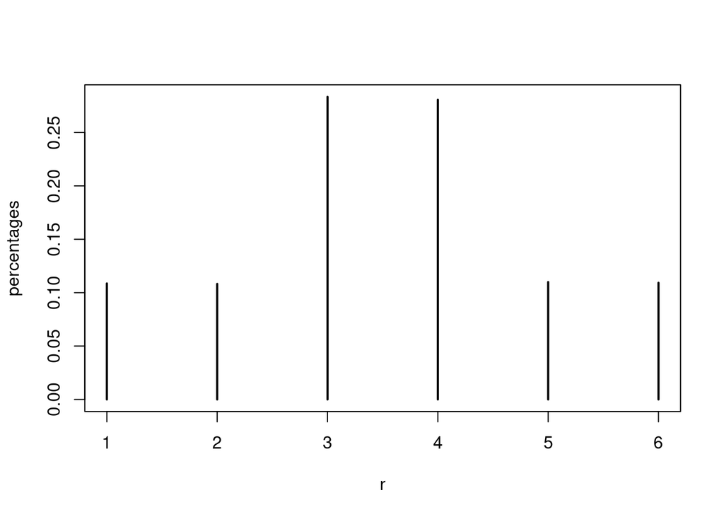

```r
plot(percentages)
```